# Setup XCMS parameters

Mar Garcia-Aloy

In this document we’re going to empirically determine some parameters for data processing.  
For that we’ll check a range of different compounds we know are present in the samples in the first and last 2 quality control (QC) samples injected along the sequence.

# Libraries

```r
library(xcms)
library(MetaboCoreUtils)
library(DT)
library(tidyverse)
```

# Data import

```r
p <- "POS"
fls <- list.files(paste0("data/", p, "_FS/fixed/"), full.names = TRUE)
fls <- fls[grep("QC_X_1_|QC_X_2|QC_X_13|QC_X_14", fls)]
fls <- fls[!grepl("eqQC", fls)]

rdata <- readMSData(fls, mode = "onDisk")
```

# Compounds

```r
cmps <- data.frame(
  rbind(
    c("Malic acid", "C4H6O5", 0.94),
    c("Trigonelline", "C7H7NO2", 0.89),
    c("Phenylalanine", "C9H11NO2", 1.83),
    c("Caftaric acid", "C13H12O9", 3.44),
    c("Catechin", "C15H14O6", 4.19),
    c("Epicatechin", "C15H14O6", 4.63),
    c("Quercetin-3-rhamnoside", "C21H20O11", 5.87),
    c("Isorhamnetin", "C16H12O7", 8.00)
  )
)
colnames(cmps) <- c("name", "formula", "RT")
if(p == "POS"){
  cmps <- cmps[!cmps$name %in% c("Malic acid", "Caftaric acid"),]
} else if(p == "NEG"){
  cmps <- cmps[!cmps$name %in% c("Trigonelline", "Phenylalanine"),]
}
cmps$RT <- as.numeric(cmps$RT)
cmps$mass <- calculateMass(cmps$formula)
datatable(cmps, rownames = FALSE) %>%
  formatRound(columns = "RT", digits = 2) %>%
  formatRound(columns = "mass", digits = 4)
```

| name | formula | RT | mass |
| --- | --- | --- | --- |
| Trigonelline | C7H7NO2 | 0.89 | 137.047678464 |
| Phenylalanine | C9H11NO2 | 1.83 | 165.078978592 |
| Catechin | C15H14O6 | 4.19 | 290.079038168 |
| Epicatechin | C15H14O6 | 4.63 | 290.079038168 |
| Quercetin-3-rhamnoside | C21H20O11 | 5.87 | 448.10056146 |
| Isorhamnetin | C16H12O7 | 8 | 316.058302724 |

# Chromatographic peak detection

Most important parameters of the `centWave` algorithm are the following:

- `peakwidth` defines the minimal and maximal expected width of the peak in retention time dimension
- `ppm`

## Peak width

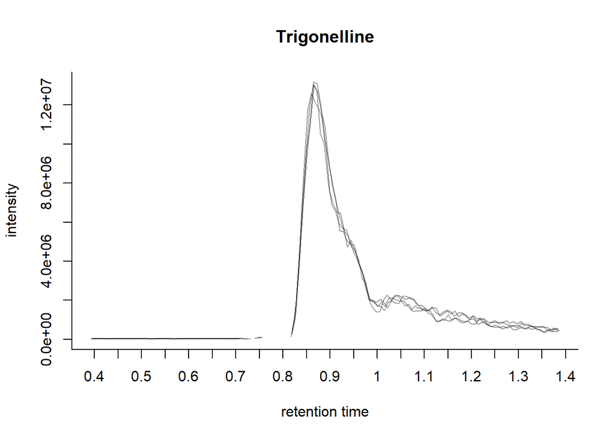

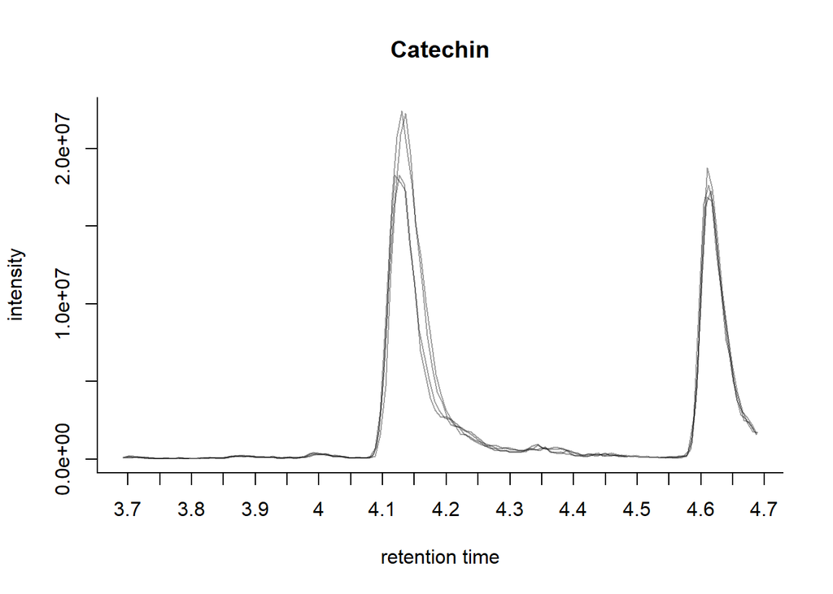

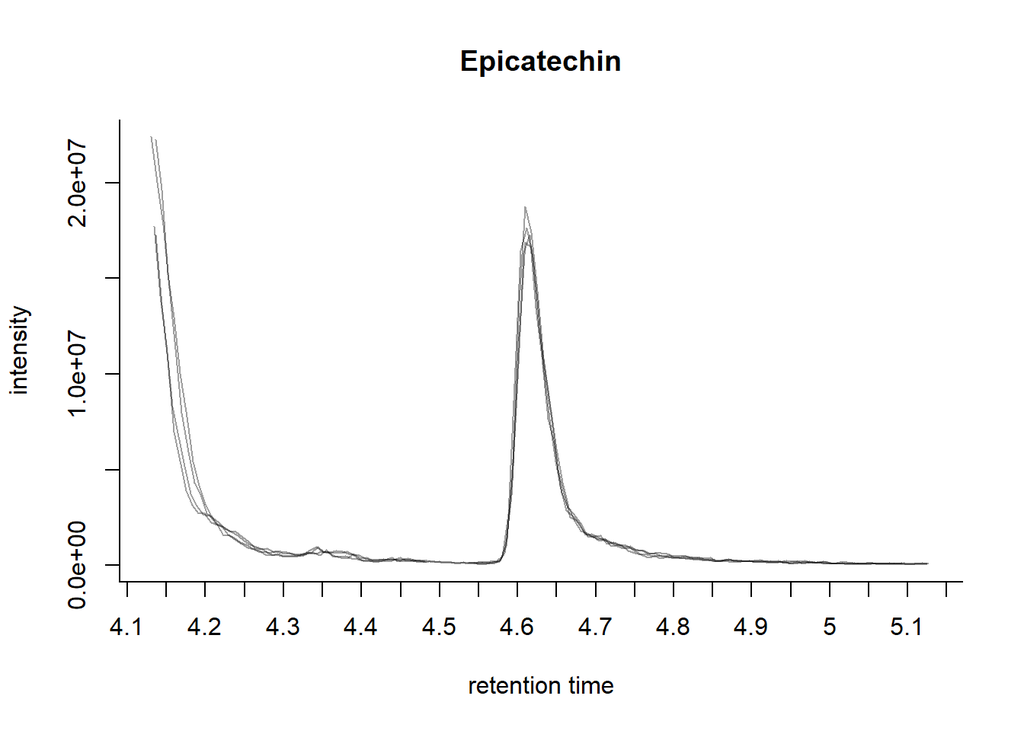

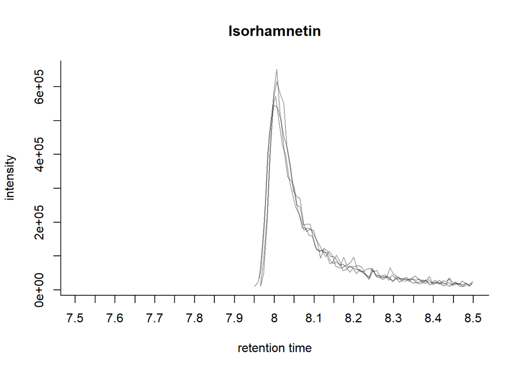

```r
if(p == "POS"){
  t_add <- "[M+H]+"
} else if(p == "NEG"){
  t_add <- "[M-H]-"
}
for(i in seq(nrow(cmps))){
  t_mz <- as.numeric(mass2mz(cmps$mass[i], t_add))
  register(SerialParam())
  t_chr <- chromatogram(rdata, mz = t_mz + 0.01*c(-1, 1), rt = cmps$RT[i]*60 + 30 * c(-1, 1))
  plot(t_chr, bty = "l", xaxt = "none", main = cmps$name[i])
  axis(1, seq(0, 15, 0.05)*60, rep(NA, length(seq(0, 15, 0.05))))
  axis(1, seq(0, 15, 0.1)*60, seq(0, 15, 0.1))
}
```

I would say that peak widths moves between 0.1 and 0.3 minutes. In order to be more flexible I’ll use a range between 0.05 and 0.4 minutes for ‘peakwidth’.

## Prefilter

```r
cmps$int_thr <- NA
for(i in seq(nrow(cmps))){
  t_mz <- as.numeric(mass2mz(cmps$mass[i], t_add))
  t_mzppm <- rdata %>%
    filterRt(cmps$RT[i]*60 + 20 * c(-1, 1)) %>%
    filterMz(t_mz + 0.02 * c(-1, 1))
  #plot(t_mzppm, type = "XIC")
  t_int <- pippo <- t_mzppm %>%
    intensity() %>%
    unlist()
  t_int <- tibble(id = names(pippo),
                  intensity = pippo) %>%
    separate(id, into = c("file", "spectrum"), sep = "\\.") %>%
    group_by(file) %>%
    arrange(desc(intensity)) %>%
    nest(data = -file)
  cmps$int_thr[i] <- t_int %>%
    mutate(thr = map_dbl(data, ~.x$intensity[4])) %>%
    pull(thr) %>%
    min()
}
datatable(cmps, rownames = FALSE) %>%
  formatRound(columns = "RT", digits = 2) %>%
  formatRound(columns = "mass", digits = 4) %>%
  formatRound(columns = "int_thr", digits = 0)
```

| name | formula | RT | mass | int_thr |
| --- | --- | --- | --- | --- |
| Trigonelline | C7H7NO2 | 0.89 | 137.047678464 | 10509316 |
| Phenylalanine | C9H11NO2 | 1.83 | 165.078978592 | 101791976 |
| Catechin | C15H14O6 | 4.19 | 290.079038168 | 14105713 |
| Epicatechin | C15H14O6 | 4.63 | 290.079038168 | 10925563 |
| Quercetin-3-rhamnoside | C21H20O11 | 5.87 | 448.10056146 | 220929.109375 |
| Isorhamnetin | C16H12O7 | 8 | 316.058302724 | 452052.1875 |

## ppm

Based on [XCMS tutorial (section: Preprocessing of LC-MS data - Chromatographic peak detection)](https://jorainer.github.io/xcmsTutorials/articles/xcms-preprocessing.html#preprocessing-of-lc-ms-data), but filtering points according to intensity instead of further restricting the mz.

```r
cmps$ppm <- NA
for(i in seq(nrow(cmps))){
  t_mz <- as.numeric(mass2mz(cmps$mass[i], t_add))
  t_mzppm <- rdata %>%
    filterRt(cmps$RT[i]*60 + 20 * c(-1, 1)) %>%
    filterMz(t_mz + 0.02 * c(-1, 1))
  #plot(t_mzppm, type = "XIC")
  t_int <- t_mzppm %>%
    intensity() %>%
    unlist() %>%
    quantile(0.5)
  t_idx <- t_mzppm %>%
    intensity() %>%
    unlist() > t_int
  t_mzppm <- t_mzppm %>%
    mz() %>%
    unlist()
  t_mzdiff <- t_mzppm[t_idx] %>%
    diff() %>%
    abs()
  cmps$ppm[i] <- paste(round(range((t_mzdiff * 1e6 / t_mz)), 0), collapse = "-")
}

datatable(cmps, rownames = FALSE) %>%
  formatRound(columns = "RT", digits = 2) %>%
  formatRound(columns = "mass", digits = 4) %>%
  formatRound(columns = "int_thr", digits = 0)
```

| name | formula | RT | mass | int_thr | ppm |
| --- | --- | --- | --- | --- | --- |
| Trigonelline | C7H7NO2 | 0.89 | 137.047678464 | 10509316 | 0-1 |
| Phenylalanine | C9H11NO2 | 1.83 | 165.078978592 | 101791976 | 0-1 |
| Catechin | C15H14O6 | 4.19 | 290.079038168 | 14105713 | 0-2 |
| Epicatechin | C15H14O6 | 4.63 | 290.079038168 | 10925563 | 0-2 |
| Quercetin-3-rhamnoside | C21H20O11 | 5.87 | 448.10056146 | 220929.109375 | 0-2 |
| Isorhamnetin | C16H12O7 | 8 | 316.058302724 | 452052.1875 | 0-1 |

Let’s use a value of 5 ppm.

## noise

Let’s check the minimum intensity measured within each spectra and then take the median of all of them.

```r
tmp <- rdata %>%
  intensity()
median(unlist(lapply(tmp, function(x) quantile(x, 0))))
```

```
## [1] 13183.47
```

## Evaluation

Let’s see if with these parameters we are able to detect these peaks in the samples.

```r
cwp <- CentWaveParam(peakwidth = c(0.05, 0.4)*60,
                     prefilter = c(5, 100000),
                     ppm = 5,
                     noise = 10000,
                     integrate = 2)
```

We set `integrate = 2` because this works particularly well for non-gaussian peak shapes and ensures that also signal from the peak’s tail is integrated.

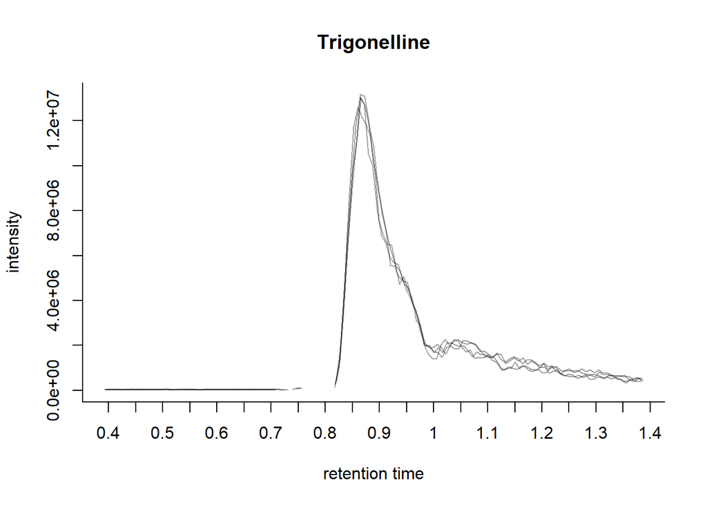

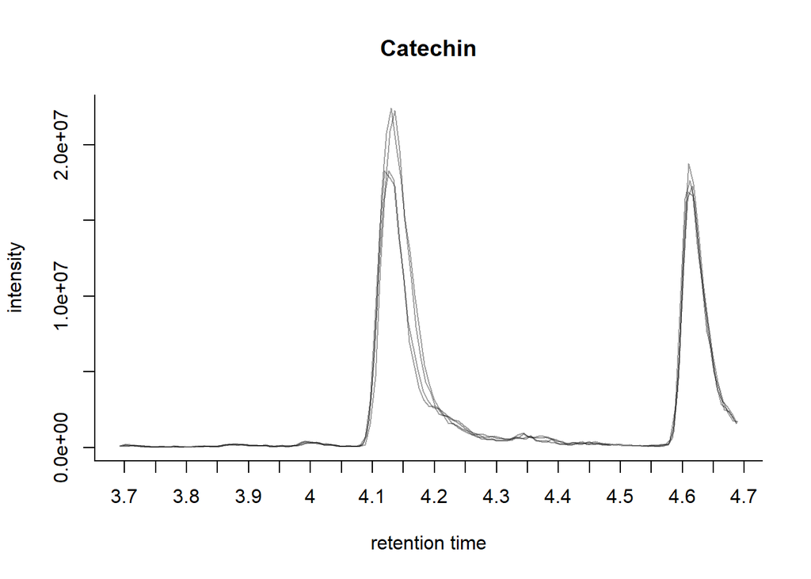

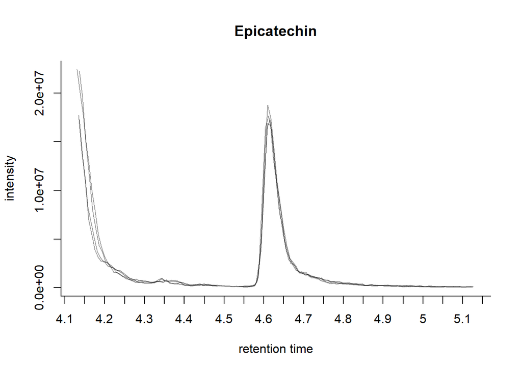

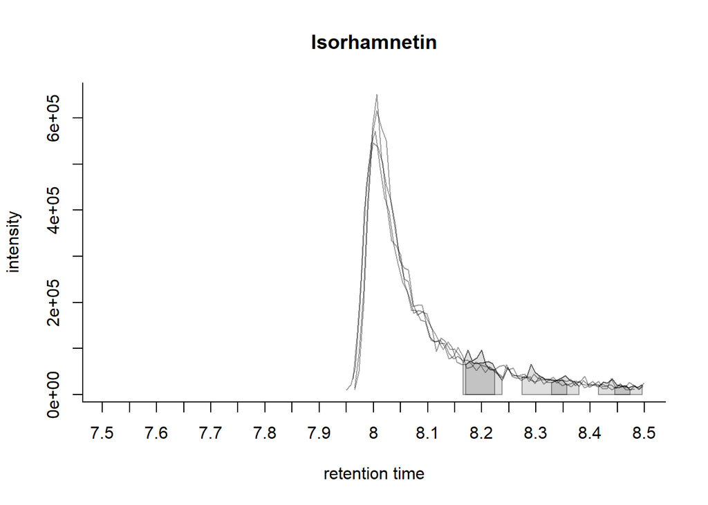

```r
for(i in seq(nrow(cmps))){
  t_mz <- as.numeric(mass2mz(cmps$mass[i], t_add))
  register(SerialParam())
  t_chr <- chromatogram(rdata, mz = t_mz + 0.01*c(-1, 1), rt = cmps$RT[i]*60 + 30 * c(-1, 1))
  t_chr2 <- findChromPeaks(t_chr, param = cwp)
  plot(t_chr2, bty = "l", xaxt = "none", main = cmps$name[i])
  axis(1, seq(0, 15, 0.05)*60, rep(NA, length(seq(0, 15, 0.05))))
  axis(1, seq(0, 15, 0.1)*60, seq(0, 15, 0.1))
  rm(t_chr2)
}
```

We are not able to detect any of these peaks…. This could be related with the ’snthresh2 parameter, which default parameter is 10. Let’s try with 5.

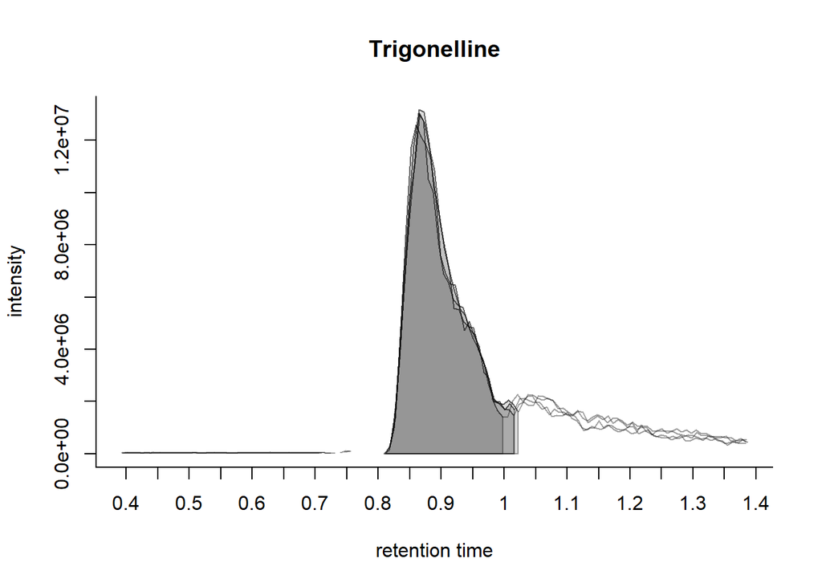

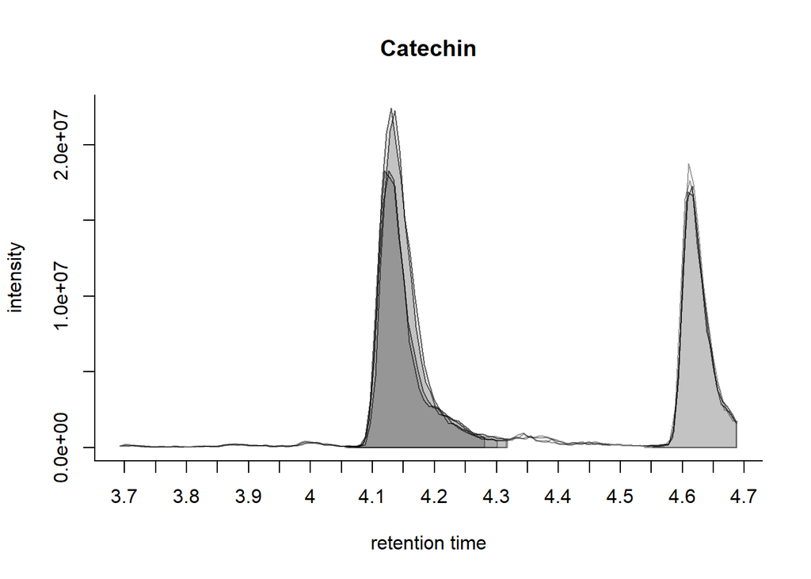

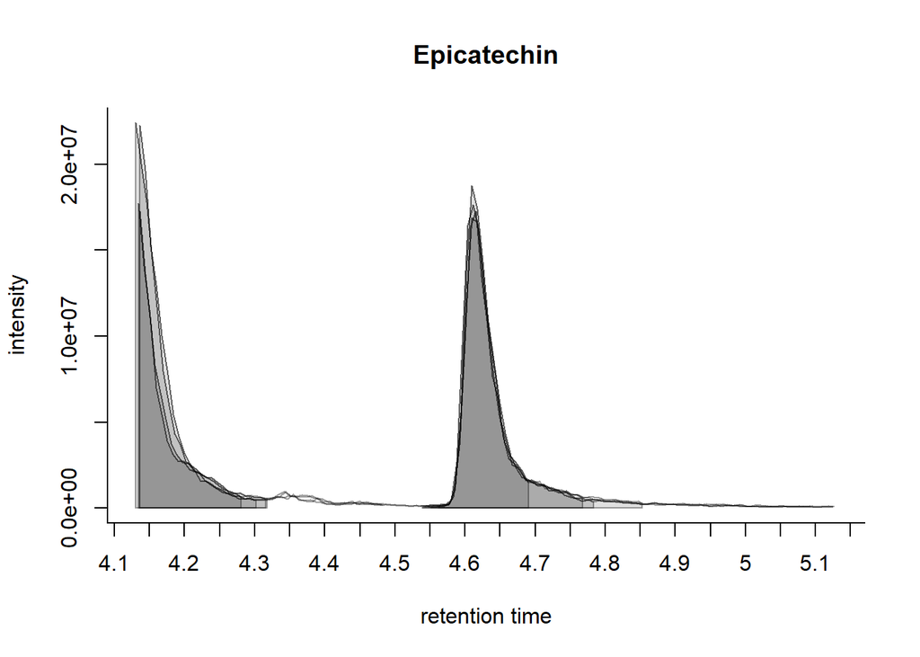

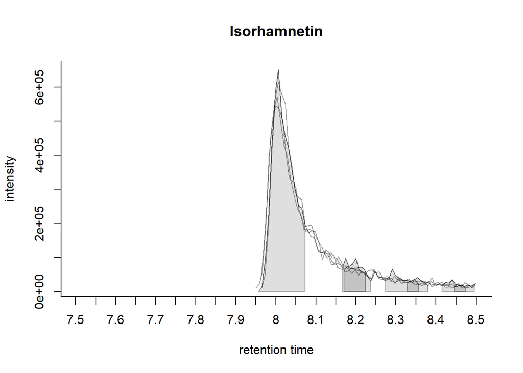

```r
cwp@snthresh <- 5
for(i in seq(nrow(cmps))){
  t_mz <- as.numeric(mass2mz(cmps$mass[i], t_add))
  register(SerialParam())
  t_chr <- chromatogram(rdata, mz = t_mz + 0.01*c(-1, 1), rt = cmps$RT[i]*60 + 30 * c(-1, 1))
  t_chr2 <- findChromPeaks(t_chr, param = cwp)
  plot(t_chr2, bty = "l", xaxt = "none", main = cmps$name[i])
  axis(1, seq(0, 15, 0.05)*60, rep(NA, length(seq(0, 15, 0.05))))
  axis(1, seq(0, 15, 0.1)*60, seq(0, 15, 0.1))
  rm(t_chr2)
}
```

# Session information

```r
Sys.time()-startpoint
```

```
## Time difference of 39.06451 secs
```

```r
#devtools::session_info()
```